# Lab 4 - Multinomial Regression

Author

Bianca Santi

Published

March 6, 2026

**Lab Goal:** Predict voting frequency using demographic variables  
**Data source:** FiveThirtyEight “Why Many Americans Don’t Vote” survey  
**Method:** Multinomial logistic regression

## Instructions

- If you are fitting a model, display the model output in a neatly formatted table. (The `tidy()` and `kable()` functions can help!)
- If you are creating a plot, use clear labels for all axes, titles, etc.
- Commit and push your work to GitHub regularly, at least after each exercise. Write short and informative commit messages.
- When you’re done, we should be able to knit the final version of the QMD in your GitHub as an HTML.

**TipWorkflow tip**

Work through the lab by running chunks **one at a time** in RStudio (Cmd/Ctrl + Enter), not by rendering the whole document. Render only at the end, once all your code is working.

This is how most R users actually work – you’d write a line, run it, check the output, and iterate. Rendering is for producing the final document. When you render, Quarto starts a fresh R session and runs every chunk top-to-bottom, so if anything is incomplete, everything downstream breaks. When you work interactively using chunks, your environment builds up as you go, so you always have your objects available to inspect and troubleshoot.

The **“Run All Chunks Above”** button (downward arrow with a bar, next to the green play button in each chunk) is another useful tool. It re-runs everything from the top of the document up to your current chunk, so all your objects are up to date before you start working on the next question.

## Setup

```r
library(nnet)
library(car)
library(tidyverse)
library(emmeans)
library(ggeffects)
library(knitr)
library(patchwork)
library(broom)
library(parameters)
library(easystats)
library(viridis)
```

# Part 1: Data Preparation

## The Data

The data for this assignment comes from an online Ipsos survey that was conducted for the FiveThirtyEight article [“Why Many Americans Don’t Vote”](https://projects.fivethirtyeight.com/non-voters-poll-2020-election/). If you’d like, you can read more about the survey design and respondents in the README of the [GitHub repo](https://github.com/fivethirtyeight/data/tree/master/non-voters) for the data, but all the necessary information is explained below.

Respondents were asked a variety of questions about their political beliefs, thoughts on multiple issues, and voting behavior. We will focus on using the demographic variables and someone’s party identification to understand whether a person is a probable voter.

The variables we’ll focus on are (definitions from the codebook in data set GitHub repo):

- `ppage`: Age of respondent
- `educ`: Highest educational attainment category
- `race`: Race of respondent, census categories. Note: all categories except Hispanic were non-Hispanic.
- `gender`: Gender of respondent
- `income_cat`: Household income category of respondent
- `Q30`: Response to the question “Generally speaking, do you think of yourself as a…”
  - 1: Republican
  - 2: Democrat
  - 3: Independent
  - 4: Another party, please specify
  - 5: No preference
  - -1: No response
- `voter_category`: past voting behavior:
  - **always**: respondent voted in all or all-but-one of the elections they were eligible in
  - **sporadic**: respondent voted in at least two, but fewer than all-but-one of the elections they were eligible in
  - **rarely/never**: respondent voted in 0 or 1 of the elections they were eligible in

```r
voter_data <- read_csv("https://raw.githubusercontent.com/fivethirtyeight/data/master/non-voters/nonvoters_data.csv")
```

The variable `Q30` contains the respondent’s political party identification. The following code simplifies `Q30` into four categories:

```r
voter_data <- voter_data %>%
  mutate(pol_ident = case_when(
    Q30 == 1 ~ "Rep",
    Q30 == 2 ~ "Dem",
    Q30 == 3 ~ "Indep",
    TRUE ~ "Other"
  ))
```

### Question 1.1

The variable `voter_category` identifies the respondent’s past voter behavior. Relevel the variable to make **rarely/never** the baseline level, followed by sporadic, then always.

**TipHint**

Use `factor()` with the `levels` argument to set the ordering. The first level becomes the baseline in `multinom()`.

```r
# Enter your code
voter_data$voter_category <- factor(voter_data$voter_category,
                                    levels = c("rarely/never", "sporadic", "always"))
```

### Question 1.2

Mean-center the age variable (`ppage`) so that the intercept reflects the log-odds for an average-aged person rather than a 0-year-old.

```r
# Enter your code
voter_data <- voter_data %>%
  mutate(
    age_centered = ppage - mean(ppage)
  )
```

# Part 2: Exploratory Data Analysis

### Question 2.1

In the [FiveThirtyEight article](https://projects.fivethirtyeight.com/non-voters-poll-2020-election/), the authors include visualizations of the relationship between voter category and demographic variables such as race, age, education, etc.

Select **two** demographic variables. For each variable, create a visualization showing its relationship with `voter_category`. Combine them into a single figure using `patchwork`. Briefly describe (1–2 sentences each) what the plots reveal.

For inspiration on recreating the FiveThirtyEight style: https://www.mikelee.co/posts/2020-02-08-recreate-fivethirtyeight-chicklet-stacked-bar-chart-in-ggplot2

**TipHint: Quick proportional bar charts**

`geom_bar(position = "fill")` gives proportions instead of counts. Map `x` to your demographic variable and `fill` to `voter_category`.

```r
# Plot 1

plot1 <- ggplot(data = voter_data) +
  geom_bar(aes(x = race, fill = voter_category),
           position = "fill") +
  labs(x = "Race", y = "Proportion of voter categories", fill = "Voter Category")
```

```r
# Plot 2
plot2 <- ggplot(data = voter_data) +
  geom_bar(aes(x = pol_ident, fill = voter_category),
           position = "fill") +
  labs(x = "Political Identity", y = "Proportion of voter categories", fill = "Voter Category")
```

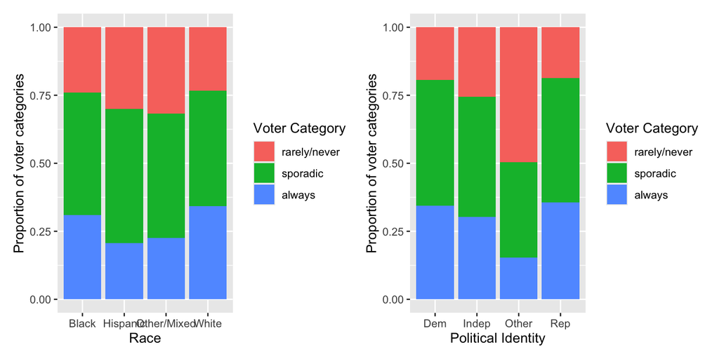

```r
# Combine with patchwork
plot1 + plot2
```

> Enter your interpretation here: The plots show that voting frequency varies both by race and by political identity. Black and white people tend to vote more frequently than Hispanic people or people of other or mixed races. People who identify as Democrats and Republicans tend to vote more frequently, with Independents voting less frequently and people who identify as “Other” voting the least frequently. ————————————————————————

# Part 3: Model Building

### Question 3.1

Fit a multinomial logistic regression model using mean-centered age, race, gender, income, and education to predict `voter_category`. Save this as `model_demo`.

You don’t need to display the output here — we’ll examine it in Part 4. If you want to peek at it, feel free to run `summary(model_demo)` in your console. There’s no real harm in displaying it via the code chunk, except that it’ll make your rendered page quite messy. `kable()` is better for clean tables.

**TipHint**

`multinom(voter_category ~ age_centered + race + gender + income_cat + educ, data = voter_data, trace = FALSE)` — the `trace = FALSE` suppresses the iteration output.

To keep the rendered document clean, add `#| results: hide` to the chunk header — this runs the code but hides the output. You can always check the output interactively by running the chunk in the console.

```r
# Enter your code
model_demo <- multinom(voter_category ~ age_centered + race + gender + income_cat + educ,
                       data = voter_data,
                       trace = FALSE)
```

### Question 3.2

Should party identification (`pol_ident`) be added to the model? Fit a second model that adds `pol_ident` to the predictors. Use `anova()` to compare the two models. Report the test statistic and your conclusion.

```r
# Enter your code
final_model <- multinom(voter_category ~ age_centered + race + gender + income_cat + educ + pol_ident,
                       data = voter_data,
                       trace = FALSE)

anova(model_demo, final_model)
```

```
                                                         Model Resid. df
1             age_centered + race + gender + income_cat + educ     11650
2 age_centered + race + gender + income_cat + educ + pol_ident     11644
  Resid. Dev   Test    Df LR stat. Pr(Chi)
1   11386.63           NA       NA      NA
2   11232.78 1 vs 2     6  153.844       0
```

> Enter your answer: The likelihood ratio test statistic is 153.844 and the p value is 0, so the test supports using the full model that includes party identification.

**Use the model you select for the remainder of the assignment.** For clarity, call your chosen model `final_model`.

# Part 4: Interpreting the Model

### Question 4.1: Overall significance

Use a likelihood ratio test (`car::Anova()` with `type = "III"`) to report the overall significance of each predictor in `final_model`.

```r
# Enter your code
kable(tidy(car::Anova(final_model, type = "III")), digits = 3)
```

| term | statistic | df | p.value |
| --- | --- | --- | --- |
| age_centered | 638.297 | 2 | 0.000 |
| race | 52.652 | 6 | 0.000 |
| gender | 6.028 | 2 | 0.049 |
| income_cat | 67.721 | 6 | 0.000 |
| educ | 154.137 | 4 | 0.000 |
| pol_ident | 153.844 | 6 | 0.000 |

### Question 4.2: Raw coefficients

Display the model output using `tidy(final_model) %>% kable(digits = 3)`.

Pick **one** comparison (e.g., “sporadic vs. rarely/never”) and do the following:

1. Write out the model equation for that comparison.
2. Interpret the coefficient for mean-centered age: what happens to the **odds** of being in that category (vs. the baseline) for each additional year of age? Report the odds ratio `exp(β)`.

**TipHint: Reading the tidy() output**

When you run `tidy(final_model)`, you’ll see a table with columns like `y.level`, `term`, `estimate`, etc. The table has **two blocks of rows** — one block where `y.level` is `sporadic`, and another where `y.level` is `always`. Each block is a separate logistic regression equation:

- The `sporadic` rows are the equation for: log-odds of sporadic **vs. rarely/never**
- The `always` rows are the equation for: log-odds of always **vs. rarely/never**

Pick one of those two blocks. The `(Intercept)` row is $\beta_0$ and the `age_centered` row is $\beta_1$ for that equation.

```r
# Enter your code
tidy(final_model) %>% kable(digits = 3)
```

| y.level | term | estimate | std.error | statistic | p.value |
| --- | --- | --- | --- | --- | --- |
| sporadic | (Intercept) | 1.732 | 0.136 | 12.724 | 0.000 |
| sporadic | age_centered | 0.046 | 0.002 | 19.654 | 0.000 |
| sporadic | raceHispanic | 0.040 | 0.128 | 0.314 | 0.753 |
| sporadic | raceOther/Mixed | -0.332 | 0.159 | -2.090 | 0.037 |
| sporadic | raceWhite | -0.078 | 0.108 | -0.719 | 0.472 |
| sporadic | genderMale | -0.090 | 0.072 | -1.248 | 0.212 |
| sporadic | income_cat$40-75k | -0.074 | 0.111 | -0.662 | 0.508 |
| sporadic | income_cat$75-125k | 0.012 | 0.107 | 0.117 | 0.907 |
| sporadic | income_catLess than $40k | -0.588 | 0.114 | -5.168 | 0.000 |
| sporadic | educHigh school or less | -0.853 | 0.097 | -8.761 | 0.000 |
| sporadic | educSome college | -0.293 | 0.095 | -3.076 | 0.002 |
| sporadic | pol_identIndep | -0.392 | 0.098 | -4.017 | 0.000 |
| sporadic | pol_identOther | -0.940 | 0.106 | -8.853 | 0.000 |
| sporadic | pol_identRep | -0.084 | 0.103 | -0.815 | 0.415 |
| always | (Intercept) | 1.490 | 0.147 | 10.146 | 0.000 |
| always | age_centered | 0.058 | 0.003 | 22.688 | 0.000 |
| always | raceHispanic | -0.341 | 0.150 | -2.277 | 0.023 |
| always | raceOther/Mixed | -0.600 | 0.185 | -3.239 | 0.001 |
| always | raceWhite | 0.127 | 0.119 | 1.071 | 0.284 |
| always | genderMale | -0.192 | 0.080 | -2.413 | 0.016 |
| always | income_cat$40-75k | 0.000 | 0.121 | -0.003 | 0.998 |
| always | income_cat$75-125k | 0.165 | 0.114 | 1.446 | 0.148 |
| always | income_catLess than $40k | -0.664 | 0.127 | -5.228 | 0.000 |
| always | educHigh school or less | -1.267 | 0.109 | -11.644 | 0.000 |
| always | educSome college | -0.330 | 0.102 | -3.226 | 0.001 |
| always | pol_identIndep | -0.562 | 0.107 | -5.259 | 0.000 |
| always | pol_identOther | -1.401 | 0.131 | -10.678 | 0.000 |
| always | pol_identRep | -0.162 | 0.110 | -1.469 | 0.142 |

```r
exp(coef(final_model)["sporadic", "age_centered"])
```

```
[1] 1.046746
```

> Enter your equation and interpretation here:

For the comparison of sporadic vs rarely/never, the equation is log_odds(sporadic/(rarely/never)) = 1.732 + 0.046 x age_centered + 0.040 x race_hispanic - 0.332 x race_other_mixed + … where each variable other than age is 0-1 coded with respect to a certain baseline (e.g., Black for race).

The coefficient for mean-centered age is 0.046, which means that the odds of being in the sporadic category as opposed to the rarely/never category increase by 1.047 with every additional year of age.

### Question 4.3: Changing the baseline

Refit the model with a **different** baseline category for `voter_category` (e.g., “always” instead of “rarely/never”). Then predict the probabilities for a specific observation using both models.

Do the coefficients change? Do the predicted probabilities change? Explain in 1–2 sentences why this happens.

**TipHint**

Use `relevel(voter_category, ref = "always")` before refitting. Use `predict(model, newdata = ..., type = "probs")` to get predicted probabilities. You can use `head(voter_data, 1)` as your newdata for a quick check.

```r
# Enter your code

voter_data$voter_category <- relevel(voter_data$voter_category, ref = "always")

releveled_model <- multinom(voter_category ~ age_centered + race + gender + income_cat + educ + pol_ident,
                       data = voter_data,
                       trace = FALSE)

kable(tidy(releveled_model), digits = 3)
```

| y.level | term | estimate | std.error | statistic | p.value |
| --- | --- | --- | --- | --- | --- |
| rarely/never | (Intercept) | -1.490 | 0.147 | -10.146 | 0.000 |
| rarely/never | age_centered | -0.058 | 0.003 | -22.688 | 0.000 |
| rarely/never | raceHispanic | 0.341 | 0.150 | 2.278 | 0.023 |
| rarely/never | raceOther/Mixed | 0.600 | 0.185 | 3.239 | 0.001 |
| rarely/never | raceWhite | -0.127 | 0.119 | -1.071 | 0.284 |
| rarely/never | genderMale | 0.192 | 0.080 | 2.413 | 0.016 |
| rarely/never | income_cat$40-75k | 0.000 | 0.121 | 0.003 | 0.998 |
| rarely/never | income_cat$75-125k | -0.165 | 0.114 | -1.446 | 0.148 |
| rarely/never | income_catLess than $40k | 0.664 | 0.127 | 5.228 | 0.000 |
| rarely/never | educHigh school or less | 1.267 | 0.109 | 11.644 | 0.000 |
| rarely/never | educSome college | 0.330 | 0.102 | 3.226 | 0.001 |
| rarely/never | pol_identIndep | 0.562 | 0.107 | 5.259 | 0.000 |
| rarely/never | pol_identOther | 1.401 | 0.131 | 10.678 | 0.000 |
| rarely/never | pol_identRep | 0.162 | 0.110 | 1.469 | 0.142 |
| sporadic | (Intercept) | 0.241 | 0.108 | 2.236 | 0.025 |
| sporadic | age_centered | -0.013 | 0.002 | -6.375 | 0.000 |
| sporadic | raceHispanic | 0.381 | 0.122 | 3.118 | 0.002 |
| sporadic | raceOther/Mixed | 0.268 | 0.156 | 1.717 | 0.086 |
| sporadic | raceWhite | -0.205 | 0.093 | -2.210 | 0.027 |
| sporadic | genderMale | 0.102 | 0.063 | 1.615 | 0.106 |
| sporadic | income_cat$40-75k | -0.073 | 0.092 | -0.795 | 0.426 |
| sporadic | income_cat$75-125k | -0.153 | 0.084 | -1.809 | 0.070 |
| sporadic | income_catLess than $40k | 0.076 | 0.103 | 0.740 | 0.459 |
| sporadic | educHigh school or less | 0.414 | 0.087 | 4.758 | 0.000 |
| sporadic | educSome college | 0.037 | 0.077 | 0.484 | 0.628 |
| sporadic | pol_identIndep | 0.170 | 0.084 | 2.021 | 0.043 |
| sporadic | pol_identOther | 0.461 | 0.121 | 3.801 | 0.000 |
| sporadic | pol_identRep | 0.078 | 0.082 | 0.952 | 0.341 |

```r
predict(final_model,
        newdata = head(voter_data, 2),
        type = "probs") %>%
  kable(digits = 3, caption = "Original model predictions")
```

| rarely/never | sporadic | always |
| --- | --- | --- |
| 0.028 | 0.394 | 0.578 |
| 0.021 | 0.423 | 0.556 |

Original model predictions

```r
predict(releveled_model,
        newdata = head(voter_data, 2),
        type = "probs") %>%
  kable(digits = 3, caption = "Releveled model predictions")
```

| always | rarely/never | sporadic |
| --- | --- | --- |
| 0.578 | 0.028 | 0.394 |
| 0.556 | 0.021 | 0.423 |

Releveled model predictions

> Enter your answer: The model coefficients change, but the predicted probabilities don’t. This is the underlying model estimations are the same, which leads to having the same predicted probabilities, but since the reference level is different all the model coefficients (which are with respect to a reference level) are also different.

# Part 5: Marginal Effects & Visualization

### Question 5.1: Predicted probabilities by age

Plot the predicted probabilities of voter category as a function of age. The code below will work once you replace `final_model` with the name of your model:

**Note**

This chunk is set to `eval: false` so the file renders before you’ve built your model. Once `final_model` exists in your environment, delete the `#| eval: false` line so the chunk runs when you render.

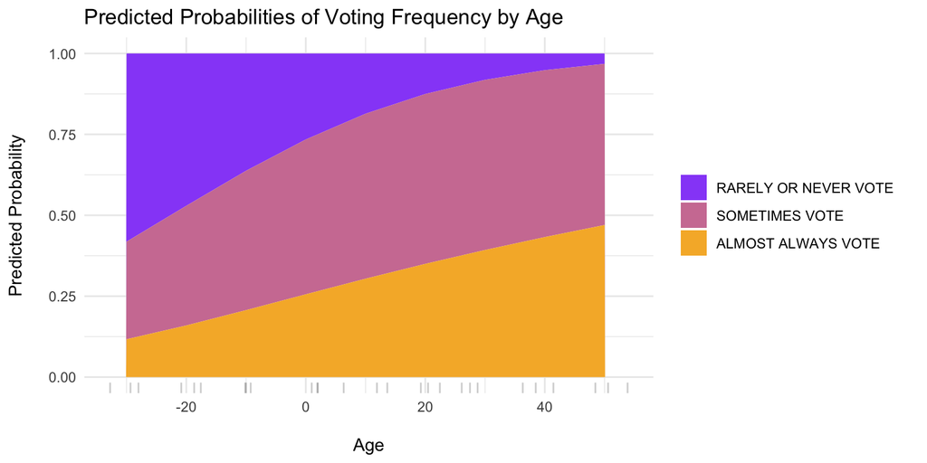

```r
ggemmeans(final_model, terms = c("age_centered")) %>%
  ggplot(., aes(x = x, y = predicted, fill = response.level)) +
  geom_area() +
  geom_rug(sides = "b", position = "jitter", alpha = .2) +
  labs(x = "\nAge", y = "Predicted Probability\n",
       title = "Predicted Probabilities of Voting Frequency by Age") +
  scale_fill_manual(
    name = NULL,
    values = c("always" = "#F6B533", "sporadic" = "#D07EA2", "rarely/never" = "#9854F7"),
    labels = c("RARELY OR NEVER VOTE    ", "SOMETIMES VOTE    ", "ALMOST ALWAYS VOTE    "),
    breaks = c("rarely/never", "sporadic", "always")
  ) +
  theme_minimal()
```

Describe the pattern you see in 1–2 sentences.

> Enter your interpretation here: As age increases, people are less likely to rarely or never vote; they are increasingly more likely to vote sometimes, although that proportion somewhat stabilizes over time, and are increasingly more likely to almost always vote.

### Question 5.2: Predicted probabilities by education

Create a similar plot showing predicted probabilities of voter category as a function of **education level**.

**TipHint**

Replace `"ppage [all]"` with `"educ"` in the `ggemmeans()` call. Since education is categorical, you may want to use `geom_col(position = "dodge")` or `geom_col(position = "fill")` instead of `geom_area()`.

[figure not shown]

```r
# Enter your code
ggemmeans(final_model, terms = c("educ")) %>%
  ggplot(., aes(x = x, y = predicted, fill = response.level)) +
  geom_col(position = "dodge") +
  geom_rug(sides = "b", position = "jitter", alpha = .2) +
  labs(x = "\nAge", y = "Predicted Probability\n",
       title = "Predicted Probabilities of Voting Frequency by Age") +
  scale_fill_manual(
    name = NULL,
    values = c("always" = "#F6B533", "sporadic" = "#D07EA2", "rarely/never" = "#9854F7"),
    labels = c("RARELY OR NEVER VOTE    ", "SOMETIMES VOTE    ", "ALMOST ALWAYS VOTE    "),
    breaks = c("rarely/never", "sporadic", "always")
  ) +
  theme_minimal()
```

> Enter your interpretation here: With higher education levels, people are more likely to vote sometimes or always and are less likely to rarely or never vote.

# Part 6: Pairwise Comparisons

### Question 6.1: Political group differences

Run the following code (replacing `final_model` with your model name) and interpret the output. The code computes estimated marginal means for each political group within each voter category, then tests pairwise differences on the log-odds scale.

**Note**

Same as Q5.1 — this chunk is set to `eval: false`. Delete that line once `final_model` exists.

```r
# Estimated marginal means: political group by voter category
multi_an_pol <- emmeans(final_model, ~ pol_ident | voter_category)

# Contrasts on the log scale (log-odds differences between voter categories, within each political group)
coefs_pol <- contrast(regrid(multi_an_pol, "log"), "trt.vs.ctrl1", by = "pol_ident")

# Display results, organized by contrast
update(coefs_pol, by = "contrast") %>%
  kable(format = "markdown", digits = 3)
```

| contrast | pol_ident | estimate | SE | df | t.ratio | p.value |
| --- | --- | --- | --- | --- | --- | --- |
| sporadic - (rarely/never) | Dem | 0.961 | 0.070 | 28 | 13.722 | 0.000 |
| always - (rarely/never) | Dem | 0.480 | 0.074 | 28 | 6.498 | 0.000 |
| sporadic - (rarely/never) | Indep | 0.591 | 0.077 | 28 | 7.643 | 0.000 |
| always - (rarely/never) | Indep | -0.049 | 0.084 | 28 | -0.590 | 0.900 |
| sporadic - (rarely/never) | Other | 0.078 | 0.087 | 28 | 0.902 | 0.747 |
| always - (rarely/never) | Other | -0.835 | 0.110 | 28 | -7.577 | 0.000 |
| sporadic - (rarely/never) | Rep | 0.883 | 0.084 | 28 | 10.469 | 0.000 |
| always - (rarely/never) | Rep | 0.327 | 0.089 | 28 | 3.672 | 0.004 |

```r
# Pairwise differences between political groups, within each contrast
contrast(coefs_pol, "revpairwise", by = "contrast") %>%
  kable(format = "markdown", digits = 3)
```

| contrast1 | contrast | estimate | SE | df | t.ratio | p.value |
| --- | --- | --- | --- | --- | --- | --- |
| Indep - Dem | sporadic - (rarely/never) | -0.370 | 0.094 | 28 | -3.933 | 0.003 |
| Other - Dem | sporadic - (rarely/never) | -0.883 | 0.103 | 28 | -8.578 | 0.000 |
| Other - Indep | sporadic - (rarely/never) | -0.513 | 0.107 | 28 | -4.807 | 0.000 |
| Rep - Dem | sporadic - (rarely/never) | -0.078 | 0.099 | 28 | -0.787 | 0.860 |
| Rep - Indep | sporadic - (rarely/never) | 0.292 | 0.099 | 28 | 2.965 | 0.029 |
| Rep - Other | sporadic - (rarely/never) | 0.805 | 0.109 | 28 | 7.404 | 0.000 |
| Indep - Dem | always - (rarely/never) | -0.529 | 0.101 | 28 | -5.255 | 0.000 |
| Other - Dem | always - (rarely/never) | -1.315 | 0.125 | 28 | -10.508 | 0.000 |
| Other - Indep | always - (rarely/never) | -0.786 | 0.129 | 28 | -6.072 | 0.000 |
| Rep - Dem | always - (rarely/never) | -0.153 | 0.104 | 28 | -1.470 | 0.468 |
| Rep - Indep | always - (rarely/never) | 0.376 | 0.104 | 28 | 3.605 | 0.006 |
| Rep - Other | always - (rarely/never) | 1.162 | 0.130 | 28 | 8.969 | 0.000 |

> Enter your interpretation here: The marginal means show the mean estimate for the effect of each political group on the log odds of being in the relevant voter frequency category (always or sporadic) as opposed to the baseline (rarely/never). For example, that means that being a Democrat increases the log odds of being in the sporadic category as opposed to rarely/never (estimate = 0.961, positive), while being an Independent decreases the log odds of being in the always category as opposed to rarely/never (estimate = -0.049, negative). The pairwise contrasts show the difference in log odds for being in one voting frequency category (always or sporadic) vs the baseline between different political groups. For example, Independents are significantly less likely to be in the sporadic category as opposed to rarely/never than Democrats (estimate = -0.370, p = 0.003).

### Question 6.2: Education level differences

Adapt the code from 6.1 to examine differences across **education levels** instead of political groups. Run it and interpret.

**TipHint**

Replace `pol_ident` with `educ` in the `emmeans()` and `contrast()` calls.

```r
# Enter your code

# Estimated marginal means: education level by voter category
multi_an_educ <- emmeans(final_model, ~ educ | voter_category)

# Contrasts on the log scale (log-odds differences between voter categories, within each political group)
coefs_educ <- contrast(regrid(multi_an_educ, "log"), "trt.vs.ctrl1", by = "educ")

# Display results, organized by contrast
update(coefs_educ, by = "contrast") %>%
  kable(format = "markdown", digits = 3)
```

| contrast | educ | estimate | SE | df | t.ratio | p.value |
| --- | --- | --- | --- | --- | --- | --- |
| sporadic - (rarely/never) | College | 0.986 | 0.076 | 28 | 12.904 | 0.000 |
| always - (rarely/never) | College | 0.477 | 0.080 | 28 | 5.960 | 0.000 |
| sporadic - (rarely/never) | High school or less | 0.187 | 0.069 | 28 | 2.705 | 0.031 |
| always - (rarely/never) | High school or less | -0.711 | 0.080 | 28 | -8.883 | 0.000 |
| sporadic - (rarely/never) | Some college | 0.707 | 0.074 | 28 | 9.512 | 0.000 |
| always - (rarely/never) | Some college | 0.167 | 0.079 | 28 | 2.114 | 0.112 |

```r
# Pairwise differences between political groups, within each contrast
contrast(coefs_educ, "revpairwise", by = "contrast") %>%
  kable(format = "markdown", digits = 3)
```

| contrast1 | contrast | estimate | SE | df | t.ratio | p.value |
| --- | --- | --- | --- | --- | --- | --- |
| High school or less - College | sporadic - (rarely/never) | -0.799 | 0.095 | 28 | -8.416 | 0.000 |
| Some college - College | sporadic - (rarely/never) | -0.278 | 0.092 | 28 | -3.030 | 0.014 |
| Some college - High school or less | sporadic - (rarely/never) | 0.520 | 0.088 | 28 | 5.920 | 0.000 |
| High school or less - College | always - (rarely/never) | -1.188 | 0.104 | 28 | -11.394 | 0.000 |
| Some college - College | always - (rarely/never) | -0.310 | 0.097 | 28 | -3.207 | 0.009 |
| Some college - High school or less | always - (rarely/never) | 0.878 | 0.098 | 28 | 8.995 | 0.000 |

> Enter your interpretation here: The marginal means show the mean estimate for the effect of each education level on the log odds of being in the relevant voter frequency category (always or sporadic) as opposed to the baseline (rarely/never). For example, that means that being college-educated increases the log odds of being in the sporadic category as opposed to rarely/never (estimate = 0.986, positive), while having an education level of high school or less decreases the log odds of being in the always category as opposed to rarely/never (estimate = -0.711, negative). The pairwise contrasts show the difference in log odds for being in one voting frequency category (always or sporadic) vs the baseline between different education levels. For example, people with high school or less education levels are significantly less likely to be in the sporadic category as opposed to rarely/never than college-educated people (estimate = -0.799, p < 0.001).

# Part 7: Write-Up

### Question 7.1

Write a **1-paragraph results section** for your final model. Your paragraph should include:

- The model type and baseline category
- Sample size
- At least one key coefficient reported as an odds ratio with a confidence interval
- The result of the likelihood ratio test for at least one predictor
- At least one finding translated into predicted probability terms (from your plots)

**WarningExample write-up (from a different dataset)**

*We used a multinomial logistic regression model (baseline category: rarely/never) to predict voting frequency from age, race, gender, income, education, and political identification (N = [n]). The likelihood ratio test indicated that political identification was a significant predictor of voter category, χ²([df]) = [value], p < .001. Among [comparison], each additional year of age was associated with [an increase/decrease] in the odds of being [category] vs. rarely/never voting (OR = [value], 95% CI [[lower], [upper]]). Predicted probability plots showed that [describe key pattern from your visualizations].*

```r
# extract sample size
sample_size <- length(unique(voter_data$RespId))


kable(tidy(final_model, exponentiate = TRUE, conf.int = TRUE), digits = 3)
```

| y.level | term | estimate | std.error | statistic | p.value | conf.low | conf.high |
| --- | --- | --- | --- | --- | --- | --- | --- |
| sporadic | (Intercept) | 5.649 | 0.136 | 12.724 | 0.000 | 4.327 | 7.376 |
| sporadic | age_centered | 1.047 | 0.002 | 19.654 | 0.000 | 1.042 | 1.052 |
| sporadic | raceHispanic | 1.041 | 0.128 | 0.314 | 0.753 | 0.810 | 1.338 |
| sporadic | raceOther/Mixed | 0.717 | 0.159 | -2.090 | 0.037 | 0.525 | 0.980 |
| sporadic | raceWhite | 0.925 | 0.108 | -0.719 | 0.472 | 0.749 | 1.143 |
| sporadic | genderMale | 0.914 | 0.072 | -1.248 | 0.212 | 0.793 | 1.053 |
| sporadic | income_cat$40-75k | 0.929 | 0.111 | -0.662 | 0.508 | 0.747 | 1.155 |
| sporadic | income_cat$75-125k | 1.013 | 0.107 | 0.117 | 0.907 | 0.822 | 1.248 |
| sporadic | income_catLess than $40k | 0.556 | 0.114 | -5.168 | 0.000 | 0.445 | 0.694 |
| sporadic | educHigh school or less | 0.426 | 0.097 | -8.761 | 0.000 | 0.352 | 0.516 |
| sporadic | educSome college | 0.746 | 0.095 | -3.076 | 0.002 | 0.619 | 0.899 |
| sporadic | pol_identIndep | 0.675 | 0.098 | -4.017 | 0.000 | 0.558 | 0.818 |
| sporadic | pol_identOther | 0.390 | 0.106 | -8.853 | 0.000 | 0.317 | 0.481 |
| sporadic | pol_identRep | 0.920 | 0.103 | -0.815 | 0.415 | 0.752 | 1.125 |
| always | (Intercept) | 4.439 | 0.147 | 10.146 | 0.000 | 3.328 | 5.920 |
| always | age_centered | 1.060 | 0.003 | 22.688 | 0.000 | 1.055 | 1.065 |
| always | raceHispanic | 0.711 | 0.150 | -2.277 | 0.023 | 0.530 | 0.954 |
| always | raceOther/Mixed | 0.549 | 0.185 | -3.239 | 0.001 | 0.381 | 0.789 |
| always | raceWhite | 1.136 | 0.119 | 1.071 | 0.284 | 0.900 | 1.433 |
| always | genderMale | 0.825 | 0.080 | -2.413 | 0.016 | 0.706 | 0.965 |
| always | income_cat$40-75k | 1.000 | 0.121 | -0.003 | 0.998 | 0.788 | 1.268 |
| always | income_cat$75-125k | 1.180 | 0.114 | 1.446 | 0.148 | 0.943 | 1.476 |
| always | income_catLess than $40k | 0.515 | 0.127 | -5.228 | 0.000 | 0.401 | 0.660 |
| always | educHigh school or less | 0.282 | 0.109 | -11.644 | 0.000 | 0.228 | 0.349 |
| always | educSome college | 0.719 | 0.102 | -3.226 | 0.001 | 0.588 | 0.878 |
| always | pol_identIndep | 0.570 | 0.107 | -5.259 | 0.000 | 0.462 | 0.703 |
| always | pol_identOther | 0.246 | 0.131 | -10.678 | 0.000 | 0.190 | 0.319 |
| always | pol_identRep | 0.851 | 0.110 | -1.469 | 0.142 | 0.685 | 1.056 |

> Enter your write-up here:

We used a multinomial logistic regression model (baseline category: rarely/never) to predict voting frequency from age, race, gender, income, education, and political identification (N = 5836). The likelihood ratio test indicated that political identification was a significant predictor of voter category, χ²(6) = 153.844, p < .001. Among those who voted rarely/never or sporadically, each additional year of age was associated with an increase in the odds of being in the sporadic category vs. rarely/never voting (OR = 1.047, 95% CI [1.042, 1.052], p < .001). Predicted probability plots showed that with higher education levels, people are more likely to vote sometimes or always and are less likely to rarely or never vote and that as age increases, people are less likely to rarely or never vote; they are increasingly more likely to vote sometimes, although that proportion somewhat stabilizes over time, and are increasingly more likely to almost always vote.